# Modelos ARCH/GARCH

José Pablo Vázquez

25/3/2021

# 1 **Bajar los datos y obtener el rendimiento**

Me decidí por utilizar Grupo Financiero Banorte, bajé el histórico de los precios desde el año 2016 hasta el día de hoy, para pasar a calcular los rendimientos del mismo.

# 2 **Probar que hay independencia de los precios**

Vamos a aplicar el estadistico de J-cuadrada para poder analizar si el comportamiento del precio en cualquier dia depende de cualquier cosa, excepto de los precios anteriores.

Si el valor del estadístico es mayor a 23.20925

Ho: se acepta la prueba que habla de la independencia de los precios

Ha: se rechaza la prueba y los precios son dependientes

| stadistic |
| --- |
| 1284.186 |

Como nuestro valor del estadístico es mayor a 23.20925 se rechaza la prueba de hipotesis nula, lo que nos habla de la dependencia de precios.

# 3 **Hacer uso de la función garchFit contenida en la librería fGarch para estimar los parámetros del modelo**

Ecuación de modelo GARCH (1,1):

$$\sigma^2 = 2.5040532\times 10^{-5} + 0.1465706R^2_{t-1} + 0.8072369\sigma^2_{t-1}$$

Ecuación de modelo GARCH(1,2):

$$\sigma^2 = 2.4949562\times 10^{-5} + 0.1460491R^2_{t-1} + 0.8078445\sigma^2_{t-1} + 10^{-8}\sigma^2_{t-2}$$

Ecuación de modelo GARCH (2,1):

$$\sigma^2 = 2.579652\times 10^{-5} + 0.1363679R^2_{t-1} + 0.0134721R^2_{t-2} + 0.802414\sigma^2_{t-1}$$

Ecuación de modelo GARCH(2,2):

$$\sigma^2 = 3.7691392\times 10^{-5} + 0.1239171R^2_{t-1} + 0.0957748R^2_{t-2} + 0.3547399\sigma^2_{t-1} + 0.3560052\sigma^2_{t-2}$$

Ecuación de modelo ARCH(1):

$$\sigma^2 = 3.693129\times 10^{-4} + 0.2962908R^2_{t-1}$$

Ecuación de modelo ARCH(2):

$$\sigma^2 = 2.7921518\times 10^{-4} + 0.2133527R^2_{t-1} + 0.2758316R^2_{t-2}$$

| A1_ics | A2_ics | G11_ics | G12_ics | G21_ics | G22_ics |
| --- | --- | --- | --- | --- | --- |
| -4.824699 | -4.883607 | -4.984417 | -4.98263 | -4.9827 | -4.981667 |

Podemos ver que gracias al criterio del menor AIC, seleccionamos el modelo GARCH(1,1) ya que es el modelo que mejor se ajusta a los datos.

| A1_func_vero | A2_func_vero | G11_func_vero | G12_func_vero | G21_func_vero | G22_func_vero |
| --- | --- | --- | --- | --- | --- |
| -3180.065 | -3219.855 | -3286.238 | -3286.062 | -3286.108 | -3286.428 |

# 4 **Una vez que tenemos el modelo ARCH/GARCH adecuado. Comparamos las estimaciones del modelo contra las estimaciones reales**

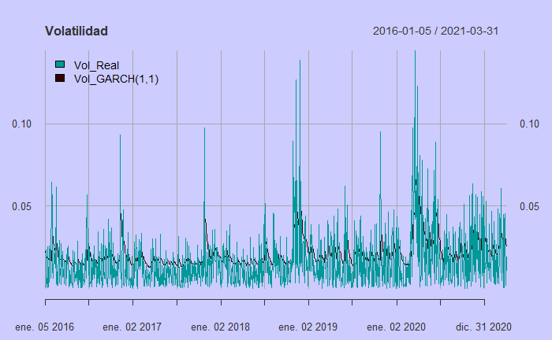

# 5 **Efectuar una estimación futura de la volatilidad. Con el comando predict**

| standardDeviation |
| --- |
| 0.02441088 |

Obtenemos que la volatilidad para el día de mañana sería de 2.44% con el comando predict, sobre nuestro modelo GARCH(1,1)

# 6 **Determinar una estimación para la volatilidad de la misma fecha que la del GARCH con los códigos de Promedio Móvil y EWMA. compara los resultados obtenidos por los tres modelos**

| standardDeviation | EWMA | Prom_Movil |
| --- | --- | --- |
| 0.02441088 | 0.01789422 | 0.02808049 |

Comparando con los modelos de Promedio Móviles y EWMA, tenemos que la volatilidad de Promedios Móviles resulta la predicción de volatilidad mas alta con 2.80%, sin embargo, considero que la estimación con el modelo GARCH(1,1) es mucho mas exata que EWMA y Promedios Móviles.